# Movie Review Analysis

Arun Kumar

July 26, 2015

### Objective

To analyse a dataset of movie rating

### Starting Point

The dataset if obtained from the below site: http://vincentarelbundock.github.io/ Dataset reference: [Movie information and user ratings from IMDB.com.](http://vincentarelbundock.github.io/Rdatasets/csv/ggplot2/movies.csv)

### Obtaining the data

1. Download the data in a csv sheet

```r
theURL <- "http://vincentarelbundock.github.io/Rdatasets/csv/ggplot2/movies.csv";
movie_data <- read.table(file = theURL, header = TRUE, sep = ",");
head(movie_data);
#State column is named as 'X". Changing the column name to US_State
colnames(movie_data)[1] <- "RefNo";
head(movie_data);
#Write the data to a CSV
write.table(movie_data, file = "movie_data.csv", sep = ",", row.names = FALSE);
#The saved file is uploaded to githib and below is the URL which will be used hereafter.
#https://raw.githubusercontent.com/arunk13/MSDA-Assignments/master/BridgeCourse/Week5/movie_data.csv
```

*Note: The tips provided in the below link is followed to clean up the data* (Introduction to data cleaning)https://cran.r-project.org/doc/contrib/de_Jonge+van_der_Loo-Introduction_to_data_cleaning_with_R.pdf

### Raw Data

```
##   RefNo                    title year length budget rating votes   r1   r2
## 1     1                        $ 1971    121     NA    6.4   348  4.5  4.5
## 2     2        $1000 a Touchdown 1939     71     NA    6.0    20  0.0 14.5
## 3     3   $21 a Day Once a Month 1941      7     NA    8.2     5  0.0  0.0
## 4     4                  $40,000 1996     70     NA    8.2     6 14.5  0.0
## 5     5 $50,000 Climax Show, The 1975     71     NA    3.4    17 24.5  4.5
## 6     6                    $pent 2000     91     NA    4.3    45  4.5  4.5
##    r3   r4   r5   r6   r7   r8   r9  r10 mpaa Action Animation Comedy
## 1 4.5  4.5 14.5 24.5 24.5 14.5  4.5  4.5           0         0      1
## 2 4.5 24.5 14.5 14.5 14.5  4.5  4.5 14.5           0         0      1
## 3 0.0  0.0  0.0 24.5  0.0 44.5 24.5 24.5           0         1      0
## 4 0.0  0.0  0.0  0.0  0.0  0.0 34.5 45.5           0         0      1
## 5 0.0 14.5 14.5  4.5  0.0  0.0  0.0 24.5           0         0      0
## 6 4.5 14.5 14.5 14.5  4.5  4.5 14.5 14.5           0         0      0
##   Drama Documentary Romance Short
## 1     1           0       0     0
## 2     0           0       0     0
## 3     0           0       0     1
## 4     0           0       0     0
## 5     0           0       0     0
## 6     1           0       0     0
```

### Cleaning and subsetting

```r
#First column can be removed.
movie_data <- movie_data_raw[-1];
```

+Summary

```r
summary(movie_data);
```

```
##                         title            year          length
##  Alice in Wonderland       :    7   Min.   :1893   Min.   :   1.00
##  Three Musketeers, The     :    7   1st Qu.:1958   1st Qu.:  74.00
##  Midsummer Night's Dream, A:    6   Median :1983   Median :  90.00
##  Skin Deep                 :    6   Mean   :1976   Mean   :  82.34
##  Underground               :    6   3rd Qu.:1997   3rd Qu.: 100.00
##  Anna Karenina             :    5   Max.   :2005   Max.   :5220.00
##  (Other)                   :58751
##      budget              rating           votes                r1
##  Min.   :        0   Min.   : 1.000   Min.   :     5.0   Min.   :  0.000
##  1st Qu.:   250000   1st Qu.: 5.000   1st Qu.:    11.0   1st Qu.:  0.000
##  Median :  3000000   Median : 6.100   Median :    30.0   Median :  4.500
##  Mean   : 13412513   Mean   : 5.933   Mean   :   632.1   Mean   :  7.014
##  3rd Qu.: 15000000   3rd Qu.: 7.000   3rd Qu.:   112.0   3rd Qu.:  4.500
##  Max.   :200000000   Max.   :10.000   Max.   :157608.0   Max.   :100.000
##  NA's   :53573
##        r2               r3               r4                r5
##  Min.   : 0.000   Min.   : 0.000   Min.   :  0.000   Min.   :  0.000
##  1st Qu.: 0.000   1st Qu.: 0.000   1st Qu.:  0.000   1st Qu.:  4.500
##  Median : 4.500   Median : 4.500   Median :  4.500   Median :  4.500
##  Mean   : 4.022   Mean   : 4.721   Mean   :  6.375   Mean   :  9.797
##  3rd Qu.: 4.500   3rd Qu.: 4.500   3rd Qu.:  4.500   3rd Qu.: 14.500
##  Max.   :84.500   Max.   :84.500   Max.   :100.000   Max.   :100.000
##
##        r6              r7               r8               r9
##  Min.   : 0.00   Min.   :  0.00   Min.   :  0.00   Min.   :  0.000
##  1st Qu.: 4.50   1st Qu.:  4.50   1st Qu.:  4.50   1st Qu.:  4.500
##  Median :14.50   Median : 14.50   Median : 14.50   Median :  4.500
##  Mean   :13.04   Mean   : 15.55   Mean   : 13.88   Mean   :  8.954
##  3rd Qu.:14.50   3rd Qu.: 24.50   3rd Qu.: 24.50   3rd Qu.: 14.500
##  Max.   :84.50   Max.   :100.00   Max.   :100.00   Max.   :100.000
##
##       r10            mpaa           Action          Animation
##  Min.   :  0.00        :53864   Min.   :0.00000   Min.   :0.00000
##  1st Qu.:  4.50   NC-17:   16   1st Qu.:0.00000   1st Qu.:0.00000
##  Median : 14.50   PG   :  528   Median :0.00000   Median :0.00000
##  Mean   : 16.85   PG-13: 1003   Mean   :0.07974   Mean   :0.06277
##  3rd Qu.: 24.50   R    : 3377   3rd Qu.:0.00000   3rd Qu.:0.00000
##  Max.   :100.00                 Max.   :1.00000   Max.   :1.00000
##
##      Comedy           Drama        Documentary         Romance
##  Min.   :0.0000   Min.   :0.000   Min.   :0.00000   Min.   :0.0000
##  1st Qu.:0.0000   1st Qu.:0.000   1st Qu.:0.00000   1st Qu.:0.0000
##  Median :0.0000   Median :0.000   Median :0.00000   Median :0.0000
##  Mean   :0.2938   Mean   :0.371   Mean   :0.05906   Mean   :0.0807
##  3rd Qu.:1.0000   3rd Qu.:1.000   3rd Qu.:0.00000   3rd Qu.:0.0000
##  Max.   :1.0000   Max.   :1.000   Max.   :1.00000   Max.   :1.0000
##
##      Short
##  Min.   :0.0000
##  1st Qu.:0.0000
##  Median :0.0000
##  Mean   :0.1609
##  3rd Qu.:0.0000
##  Max.   :1.0000
##
```

- Out of 58788 records, 53573 record does not have information about the budget. I will remove the budget column from my dataset, as i feel that as the most of the observation is missing this variable data, hence it will not help me infer any understanding.

```r
movie_data <- movie_data[-4];
```

Similarly 53864 movies are missing mpaa ratings. Lets find out the types of movies which are missing the mpaa ratings.

```
##   year freq
## 1 2005  289
## 2 2004 1596
## 3 2003 1747
## 4 2002 1667
## 5 2001 1611
```

### Binning observation into decades of year

Number of observation with missing year information : 0

For ease of analysis, we will subset the data from 1900 - till date.

Number of movies in by decade

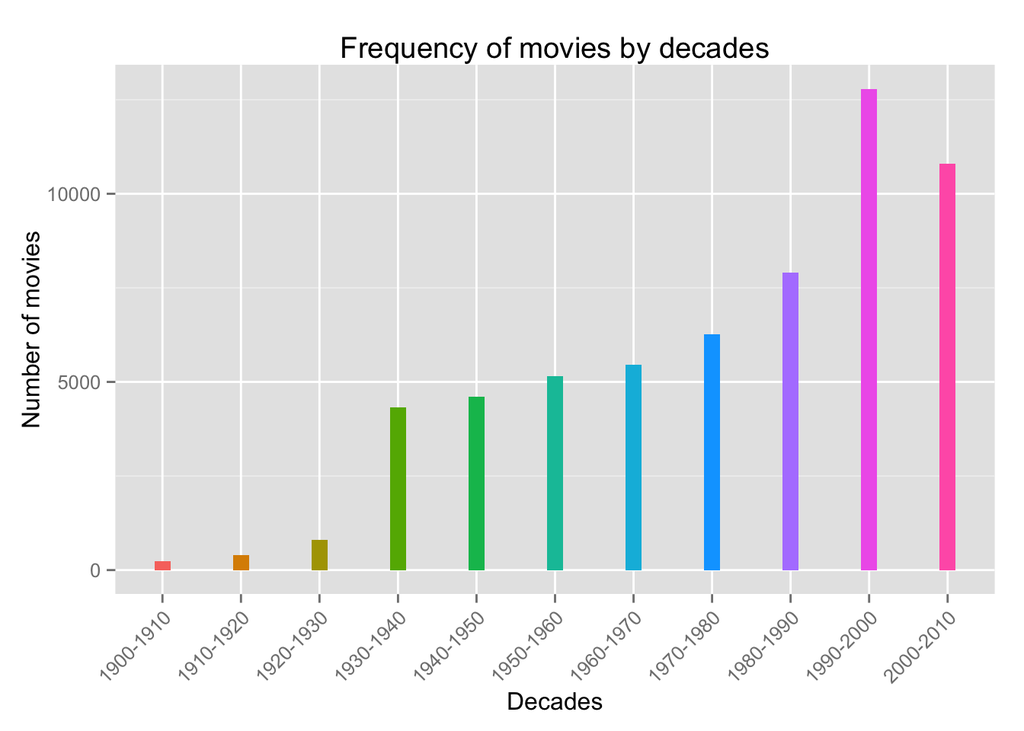

```r
freq_decade_movie <- count(movie_data, c("decade"));
g_movie <- ggplot(data = freq_decade_movie, aes(y = freq, x = decade, fill = decade));
g_movie + geom_bar(stat = "identity", width = 0.2, , position = "identity") + guides(fill = FALSE) + xlab("Decades") + ylab("Number of movies") + ggtitle("Frequency of movies by decades") + theme(axis.text.x = element_text(angle = 45, hjust = 1));
```

### A Study on the popularity of movies

*Note: The dataset is not in a structure where we can compare the distribution of the ratings for various genres. Hence, the data frame is first melted using reshape2 package*

```r
require(reshape2);
```

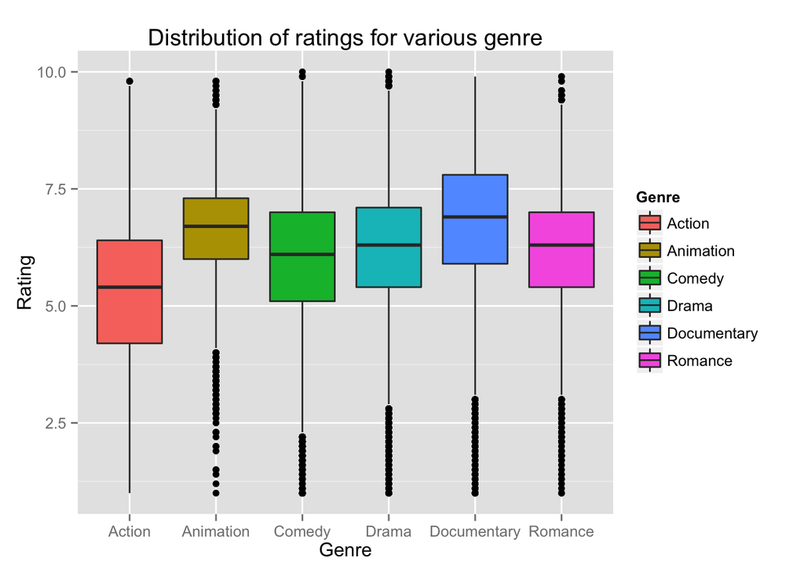

```r
movie_data_sub <- movie_data[, c(1,2,4,5,17,18,19,20,21,22)];
movie_data_sub <- melt(movie_data_sub, c(1,2,3,4));
names(movie_data_sub)[5] <- c("Genre");
movie_data_sub <- subset(movie_data_sub, value == 1);
g_genre <- ggplot(data = movie_data_sub, aes(x = Genre, y = rating, fill = Genre));
g_genre + geom_boxplot() + xlab("Genre") + ylab("Rating") + ggtitle("Distribution of ratings for various genre");
```

Before inferring popularity of each genre, we will also have to see the frequency of movies in each genre.

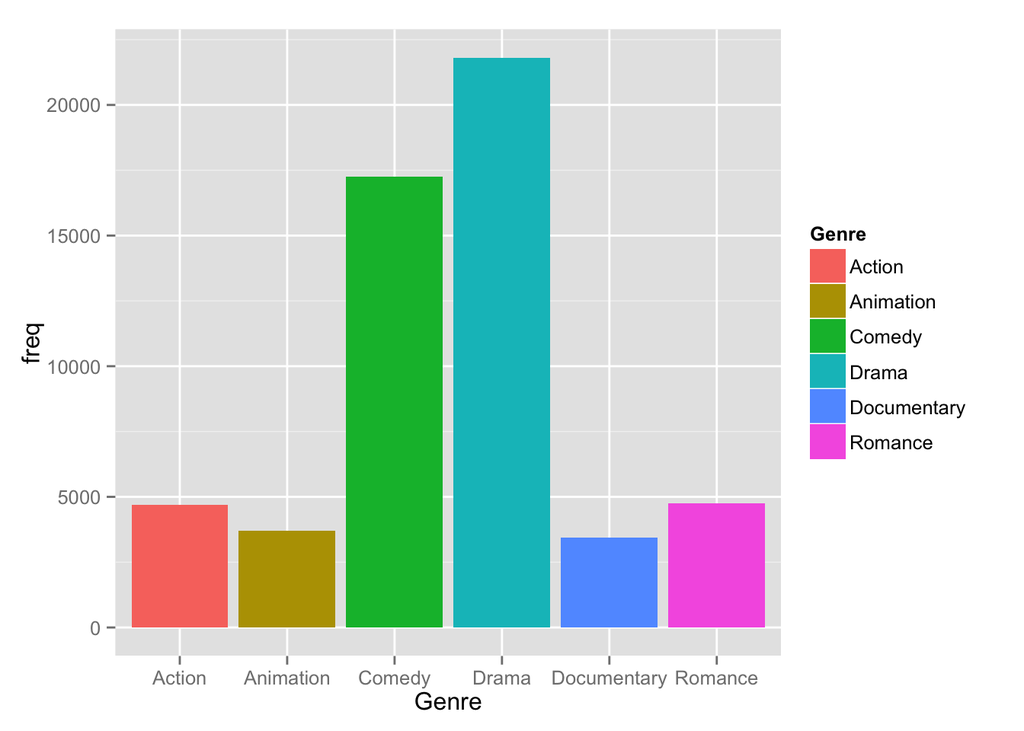

### Evolution of animation movies

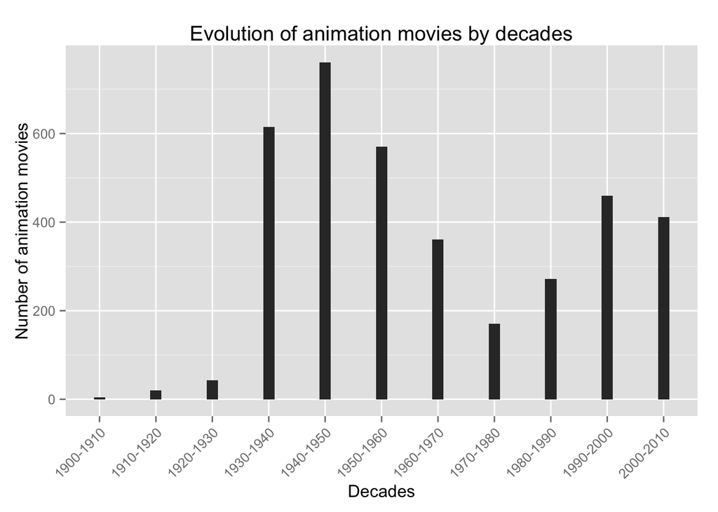

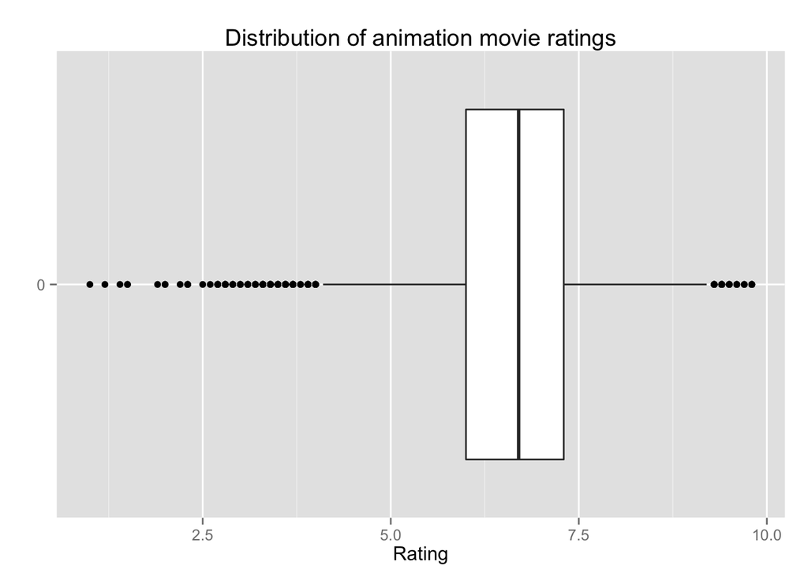

Summary of ratings for animation movie

```r
summary(movie_anim$rating);
```

```
##    Min. 1st Qu.  Median    Mean 3rd Qu.    Max.
##   1.000   6.000   6.700   6.584   7.300   9.800
```

### Probability

Probability(animation movie) = total number of animation movie/total movie in sample space = 0.0628

Probability(movie rating > 6 and movie being animation) = 0.0454

Probability of a movie getting rating greater than 6 provided movie is animation movie =

0.7228 = 72.2764 %